# Regression

Supervised Machine Learning: Regression

## 01. Main Objective of the Analysis

#### The primary objective is to predict the GDP growth using various features from the 'global data on sustainable energy'dataset. This analysis will focus on building predictive models while ensuring interpretability of the results.

## 02. Brief description of the Dataset and Summary of its Attributes

#### The 'global data on sustainable energy' dataset includes attributes related to energy consumption and sustainability. Key columns include:

#### ~Entity: Country or region

#### ~Year: Year of the data point

#### ~Access to electricity (% of population)

#### ~Access to clean fuels for cooking

#### ~Renewable-electricity-generating-capacity-per-capita

#### ~Financial flows to developing countries (US dollars)

#### ~Renewable energy share in total final energy consumption (in percentage)

#### ~Electricity from fossil fuels (TWh)

#### ~Electricity from nuclear (TWh)

#### ~Electricity from renewables (TWh)

#### ~Low-carbon electricity (% electricity)

#### ~Primary energy consumption per capita (kWh/person)

#### ~Energy intensity level of primary energy (MJ/$2017 PPP GDP)

#### ~Value_co2_emissions_kt_by_country

#### ~Renewables (% equivalent primary energy)

#### ~gdp_growth: Target variable

#### ~Density (P/Km2)

#### ~Land Area (Km2)

## 03. Data Exploration, Cleaning and Feature Engineering

### Import Libraries

```python
import pandas as pd
import numpy as np
import seaborn as sns
import matplotlib.pyplot as plt
from sklearn.model_selection import train_test_split, KFold, cross_val_score
from sklearn.preprocessing import PolynomialFeatures, StandardScaler, OneHotEncoder
from sklearn.linear_model import LinearRegression, Ridge, Lasso, ElasticNet
from sklearn.metrics import mean_squared_error
from sklearn.compose import ColumnTransformer
from sklearn.pipeline import Pipeline
from scipy import stats
```

### Reading and Understanding Data

```python
import warnings

# Suppress all warnings
warnings.filterwarnings('ignore')
```

```python
#Load dataset
df = pd.read_csv('/Users/nahthiyaashar/Downloads/global-data-on-sustainable-energy (1).csv')
```

```python
df.info()
```

```
<class 'pandas.core.frame.DataFrame'>
RangeIndex: 3649 entries, 0 to 3648
Data columns (total 21 columns):
 #   Column                                                            Non-Null Count  Dtype
---  ------                                                            --------------  -----
 0   Entity                                                            3649 non-null   object
 1   Year                                                              3649 non-null   int64
 2   Access to electricity (% of population)                           3639 non-null   float64
 3   Access to clean fuels for cooking                                 3480 non-null   float64
 4   Renewable-electricity-generating-capacity-per-capita              2718 non-null   float64
 5   Financial flows to developing countries (US $)                    1560 non-null   float64
 6   Renewable energy share in the total final energy consumption (%)  3455 non-null   float64
 7   Electricity from fossil fuels (TWh)                               3628 non-null   float64
 8   Electricity from nuclear (TWh)                                    3523 non-null   float64
 9   Electricity from renewables (TWh)                                 3628 non-null   float64
 10  Low-carbon electricity (% electricity)                            3607 non-null   float64
 11  Primary energy consumption per capita (kWh/person)                3649 non-null   float64
 12  Energy intensity level of primary energy (MJ/$2017 PPP GDP)       3442 non-null   float64
 13  Value_co2_emissions_kt_by_country                                 3221 non-null   float64
 14  Renewables (% equivalent primary energy)                          1512 non-null   float64
 15  gdp_growth                                                        3332 non-null   float64
 16  gdp_per_capita                                                    3367 non-null   float64
 17  Density\n(P/Km2)                                                  3648 non-null   float64
 18  Land Area(Km2)                                                    3648 non-null   float64
 19  Latitude                                                          3648 non-null   float64
 20  Longitude                                                         3648 non-null   float64
dtypes: float64(19), int64(1), object(1)
memory usage: 598.8+ KB
```

```python
df.describe()
```

|  | Year | Access to electricity (% of population) | Access to clean fuels for cooking | Renewable-electricity-generating-capacity-per-capita | Financial flows to developing countries (US $) | Renewable energy share in the total final energy consumption (%) | Electricity from fossil fuels (TWh) | Electricity from nuclear (TWh) | Electricity from renewables (TWh) | Low-carbon electricity (% electricity) | Primary energy consumption per capita (kWh/person) | Energy intensity level of primary energy (MJ/$2017 PPP GDP) | Value_co2_emissions_kt_by_country | Renewables (% equivalent primary energy) | gdp_growth | gdp_per_capita | Density\n(P/Km2) | Land Area(Km2) | Latitude | Longitude |
| --- | --- | --- | --- | --- | --- | --- | --- | --- | --- | --- | --- | --- | --- | --- | --- | --- | --- | --- | --- | --- |
| count | 3649.000000 | 3639.000000 | 3480.000000 | 2718.000000 | 1.560000e+03 | 3455.000000 | 3628.000000 | 3523.000000 | 3628.000000 | 3607.000000 | 3649.000000 | 3442.000000 | 3.221000e+03 | 1512.000000 | 3332.000000 | 3367.000000 | 3648.000000 | 3.648000e+03 | 3648.000000 | 3648.000000 |
| mean | 2010.038367 | 78.933702 | 63.255287 | 113.137498 | 9.422400e+07 | 32.638165 | 70.365003 | 13.450190 | 23.968010 | 36.801182 | 25743.981745 | 5.307345 | 1.598665e+05 | 11.986707 | 3.441610 | 13283.774348 | 223.573191 | 6.332135e+05 | 18.246388 | 14.822695 |
| std | 6.054228 | 30.275541 | 39.043658 | 244.167256 | 2.981544e+08 | 29.894901 | 348.051866 | 73.006623 | 104.431085 | 34.314884 | 34773.221366 | 3.532020 | 7.736611e+05 | 14.994644 | 5.686720 | 19709.866716 | 683.463448 | 1.585519e+06 | 24.159232 | 66.348148 |
| min | 2000.000000 | 1.252269 | 0.000000 | 0.000000 | 0.000000e+00 | 0.000000 | 0.000000 | 0.000000 | 0.000000 | 0.000000 | 0.000000 | 0.110000 | 1.000000e+01 | 0.000000 | -62.075920 | 111.927225 | 2.000000 | 2.100000e+01 | -40.900557 | -175.198242 |
| 25% | 2005.000000 | 59.800890 | 23.175000 | 3.540000 | 2.600000e+05 | 6.515000 | 0.290000 | 0.000000 | 0.040000 | 2.877847 | 3116.737300 | 3.170000 | 2.020000e+03 | 2.137095 | 1.383302 | 1337.813437 | 34.000000 | 2.571300e+04 | 3.202778 | -11.779889 |
| 50% | 2010.000000 | 98.361570 | 83.150000 | 32.910000 | 5.665000e+06 | 23.300000 | 2.970000 | 0.000000 | 1.470000 | 27.865068 | 13120.570000 | 4.300000 | 1.050000e+04 | 6.290766 | 3.559855 | 4578.633208 | 87.000000 | 1.176000e+05 | 17.189877 | 19.145136 |
| 75% | 2015.000000 | 100.000000 | 100.000000 | 112.210000 | 5.534750e+07 | 55.245000 | 26.837500 | 0.000000 | 9.600000 | 64.403792 | 33892.780000 | 6.027500 | 6.058000e+04 | 16.841638 | 5.830099 | 15768.615365 | 219.000000 | 5.131200e+05 | 38.969719 | 46.199616 |
| max | 2020.000000 | 100.000000 | 100.000000 | 3060.190000 | 5.202310e+09 | 96.040000 | 5184.130000 | 809.410000 | 2184.940000 | 100.000010 | 262585.700000 | 32.570000 | 1.070722e+07 | 86.836586 | 123.139555 | 123514.196700 | 8358.000000 | 9.984670e+06 | 64.963051 | 178.065032 |

### Data Cleaning and Data Wrangling

```python
# Drop rows with missing target values
df = df.dropna(subset=['gdp_growth'])
```

```python
# Check for missing values
df.isnull().sum()
```

```
Entity                                                                 0
Year                                                                   0
Access to electricity (% of population)                                8
Access to clean fuels for cooking                                    138
Renewable-electricity-generating-capacity-per-capita                 889
Financial flows to developing countries (US $)                      1865
Renewable energy share in the total final energy consumption (%)     178
Electricity from fossil fuels (TWh)                                   21
Electricity from nuclear (TWh)                                       126
Electricity from renewables (TWh)                                     21
Low-carbon electricity (% electricity)                                42
Primary energy consumption per capita (kWh/person)                     0
Energy intensity level of primary energy (MJ/$2017 PPP GDP)          159
Value_co2_emissions_kt_by_country                                    206
Renewables (% equivalent primary energy)                            1885
gdp_growth                                                             0
gdp_per_capita                                                         5
Density\n(P/Km2)                                                       0
Land Area(Km2)                                                         0
Latitude                                                               0
Longitude                                                              0
dtype: int64
```

```python
# Fill missing values with the mean
df['Access to electricity (% of population)'].fillna(df['Access to electricity (% of population)'].mean(), inplace=True)
df['Access to clean fuels for cooking'].fillna(df['Access to clean fuels for cooking'].mean(), inplace=True)
df['Renewable-electricity-generating-capacity-per-capita'].fillna(df['Renewable-electricity-generating-capacity-per-capita'].mean(), inplace=True)
df['Financial flows to developing countries (US $)'].fillna(df['Financial flows to developing countries (US $)'].mean(), inplace=True)
df['Renewable energy share in the total final energy consumption (%)'].fillna(df['Renewable energy share in the total final energy consumption (%)'].mean(), inplace=True)
df['Electricity from fossil fuels (TWh)'].fillna(df['Electricity from fossil fuels (TWh)'].mean(), inplace=True)
df['Electricity from nuclear (TWh)'].fillna(df['Electricity from nuclear (TWh)'].mean(), inplace=True)
df['Electricity from renewables (TWh)'].fillna(df['Electricity from renewables (TWh)'].mean(), inplace=True)
df['Low-carbon electricity (% electricity)'].fillna(df['Low-carbon electricity (% electricity)'].mean(), inplace=True)
df['Energy intensity level of primary energy (MJ/$2017 PPP GDP)'].fillna(df['Energy intensity level of primary energy (MJ/$2017 PPP GDP)'].mean(), inplace=True)
df['Value_co2_emissions_kt_by_country'].fillna(df['Value_co2_emissions_kt_by_country'].mean(), inplace=True)
df['Renewables (% equivalent primary energy)'].fillna(df['Renewables (% equivalent primary energy)'].mean(), inplace=True)
df['gdp_per_capita'].fillna(df['gdp_per_capita'].mean(), inplace=True)
```

```python
df.isnull().sum()
```

```
Entity                                                              0
Year                                                                0
Access to electricity (% of population)                             0
Access to clean fuels for cooking                                   0
Renewable-electricity-generating-capacity-per-capita                0
Financial flows to developing countries (US $)                      0
Renewable energy share in the total final energy consumption (%)    0
Electricity from fossil fuels (TWh)                                 0
Electricity from nuclear (TWh)                                      0
Electricity from renewables (TWh)                                   0
Low-carbon electricity (% electricity)                              0
Primary energy consumption per capita (kWh/person)                  0
Energy intensity level of primary energy (MJ/$2017 PPP GDP)         0
Value_co2_emissions_kt_by_country                                   0
Renewables (% equivalent primary energy)                            0
gdp_growth                                                          0
gdp_per_capita                                                      0
Density\n(P/Km2)                                                    0
Land Area(Km2)                                                      0
Latitude                                                            0
Longitude                                                           0
dtype: int64
```

```python
# List of numerical columns (excluding 'Entity')
numerical_columns = ['Access to electricity (% of population)',
                      'Access to clean fuels for cooking',
                      'Renewable-electricity-generating-capacity-per-capita',
                      'Financial flows to developing countries (US $)',
                      'Renewable energy share in the total final energy consumption (%)',
                      'Electricity from fossil fuels (TWh)',
                      'Electricity from nuclear (TWh)',
                      'Electricity from renewables (TWh)',
                      'Low-carbon electricity (% electricity)',
                      'Primary energy consumption per capita (kWh/person)',
                      'Energy intensity level of primary energy (MJ/$2017 PPP GDP)',
                      'Value_co2_emissions_kt_by_country',
                      'Renewables (% equivalent primary energy)',
                      'gdp_growth',
                      'gdp_per_capita',
                      'Land Area(Km2)',
                      'Latitude',
                      'Longitude']

# Handle missing values and convert numerical columns
for col in numerical_columns:
    # Fill missing values with the median of the column (or choose another method)
    df[col].fillna(df[col].median(), inplace=True)
```

### Feature Engineering

#### I will be creating a new feature called 'Renewable_Energy_Interaction'. This will capture the combined effect of the proportion of renewable energy in the total energy consumption and the absolute amount of electricity derived from renewable sources. It will help to understand how these two factors interact and contribute to the renewable energy context:

```python
df['Renewable_Energy_Interaction'] = df['Renewable energy share in the total final energy consumption (%)'] * df['Electricity from renewables (TWh)']
```

#### Let's check skewness and assess the distribution for all columns in the DataFrame.

```python
from scipy.stats import skew

# Calculate skewness
skewness = df.select_dtypes(include=['float64', 'int64']).apply(lambda x: skew(x.dropna()))
print('Skewness for each column:')
print(skewness)
```

```
Skewness for each column:
Year                                                                -0.016324
Access to electricity (% of population)                             -1.216445
Access to clean fuels for cooking                                   -0.509217
Renewable-electricity-generating-capacity-per-capita                 6.418881
Financial flows to developing countries (US $)                      12.699831
Renewable energy share in the total final energy consumption (%)     0.643042
Electricity from fossil fuels (TWh)                                  9.003465
Electricity from nuclear (TWh)                                       8.322708
Electricity from renewables (TWh)                                   10.603727
Low-carbon electricity (% electricity)                               0.454628
Primary energy consumption per capita (kWh/person)                   2.598672
Energy intensity level of primary energy (MJ/$2017 PPP GDP)          2.650555
Value_co2_emissions_kt_by_country                                    9.491439
Renewables (% equivalent primary energy)                             3.289954
gdp_growth                                                           2.540914
gdp_per_capita                                                       2.381411
Density\n(P/Km2)                                                     9.579102
Land Area(Km2)                                                       4.482328
Latitude                                                            -0.248208
Longitude                                                           -0.081314
Renewable_Energy_Interaction                                        11.621346
dtype: float64
```

#### Now let's adjust skewness and move towards more distributed data:

```python
# Apply log transformation
log_columns = ['Financial flows to developing countries (US $)', 'Electricity from renewables (TWh)',
                'Electricity from fossil fuels (TWh)', 'Electricity from nuclear (TWh)',
                'Renewable energy share in the total final energy consumption (%)',
                'Primary energy consumption per capita (kWh/person)',
                'Energy intensity level of primary energy (MJ/$2017 PPP GDP)',
                'Value_co2_emissions_kt_by_country']

for col in log_columns:
    df[f'Log_{col}'] = np.log1p(df[col])
```

```python
# Apply square root transformation
sqrt_columns = ['Renewables (% equivalent primary energy)',  'gdp_per_capita',
                'Land Area(Km2)', 'Low-carbon electricity (% electricity)']

for col in sqrt_columns:
    df[f'Sqrt_{col}'] = np.sqrt(df[col])
```

```python
from sklearn.preprocessing import PowerTransformer

yeojohnson_columns = ['Log_Financial flows to developing countries (US $)',
                      'Log_Electricity from renewables (TWh)',
                      'Log_Electricity from fossil fuels (TWh)',
                      'Log_Electricity from nuclear (TWh)',
                      'Log_Renewable energy share in the total final energy consumption (%)',
                      'Log_Primary energy consumption per capita (kWh/person)',
                      'Log_Energy intensity level of primary energy (MJ/$2017 PPP GDP)',
                      'Log_Value_co2_emissions_kt_by_country',
                      'Sqrt_Renewables (% equivalent primary energy)',
                      'Sqrt_gdp_per_capita',
                      'Sqrt_Land Area(Km2)',
                      'Sqrt_Low-carbon electricity (% electricity)']

yeojohnson_transformer = PowerTransformer(method='yeo-johnson', standardize=False)
df[yeojohnson_columns] = yeojohnson_transformer.fit_transform(df[yeojohnson_columns])
```

```python
# Recalculate skewness
skewness_transformed = df[yeojohnson_columns].apply(lambda x: skew(x.dropna()))
print('Skewness after transformations:')
print(skewness_transformed)
```

```
Skewness after transformations:
Log_Financial flows to developing countries (US $)                     -0.563491
Log_Electricity from renewables (TWh)                                   0.081704
Log_Electricity from fossil fuels (TWh)                                 0.006901
Log_Electricity from nuclear (TWh)                                      1.513250
Log_Renewable energy share in the total final energy consumption (%)   -0.384713
Log_Primary energy consumption per capita (kWh/person)                 -0.159970
Log_Energy intensity level of primary energy (MJ/$2017 PPP GDP)         0.038872
Log_Value_co2_emissions_kt_by_country                                  -0.049461
Sqrt_Renewables (% equivalent primary energy)                           0.204417
Sqrt_gdp_per_capita                                                     0.001508
Sqrt_Land Area(Km2)                                                    -0.023739
Sqrt_Low-carbon electricity (% electricity)                            -0.327576
dtype: float64
```

```python
from scipy.stats import shapiro

# Perform Shapiro-Wilk test
def perform_shapiro_test(column):
    stat, p_value = shapiro(column.dropna())
    return p_value

for column in yeojohnson_columns:
    p_value = perform_shapiro_test(df[column])
    print(f'{column} p-value: {p_value}')
```

```
Log_Financial flows to developing countries (US $) p-value: 0.0
Log_Electricity from renewables (TWh) p-value: 1.5180266264030743e-41
Log_Electricity from fossil fuels (TWh) p-value: 7.428246165106397e-38
Log_Electricity from nuclear (TWh) p-value: 0.0
Log_Renewable energy share in the total final energy consumption (%) p-value: 7.437137661701456e-36
Log_Primary energy consumption per capita (kWh/person) p-value: 2.2314190963841965e-16
Log_Energy intensity level of primary energy (MJ/$2017 PPP GDP) p-value: 3.754153943636513e-24
Log_Value_co2_emissions_kt_by_country p-value: 2.028415846747067e-12
Sqrt_Renewables (% equivalent primary energy) p-value: 0.0
Sqrt_gdp_per_capita p-value: 1.7339393927666378e-20
Sqrt_Land Area(Km2) p-value: 2.4020052784757817e-17
Sqrt_Low-carbon electricity (% electricity) p-value: 1.289040444347756e-40
```

#### Next, I will do categroical encoding on 'Entity':

```python
from sklearn.preprocessing import OneHotEncoder
from sklearn.compose import ColumnTransformer

# Define categorical features
categorical_features = ['Entity']

# Initialize ColumnTransformer with OneHotEncoder for categorical features
preprocessor = ColumnTransformer(
    transformers=[
        ('cat', OneHotEncoder(), categorical_features)
    ],
    remainder='passthrough'
)

# Apply transformation
df_encoded = preprocessor.fit_transform(df)

# Print the shape of the transformed data
print(f"Shape of df_encoded: {df_encoded.shape}")

# Extract feature names from the ColumnTransformer
feature_names = preprocessor.get_feature_names_out()
print(f"Number of feature names: {len(feature_names)}")
print("Feature names:", feature_names[:10])  # Print a sample of feature names for verification

# Convert CSR matrix to dense NumPy array
dense_matrix = df_encoded.toarray()

# Create DataFrame
df_encoded = pd.DataFrame(dense_matrix, columns=feature_names)
df_encoded = pd.DataFrame(df_encoded, columns=feature_names)
```

```
Shape of df_encoded: (3332, 197)
Number of feature names: 197
Feature names: ['cat__Entity_Afghanistan' 'cat__Entity_Albania' 'cat__Entity_Algeria'
 'cat__Entity_Angola' 'cat__Entity_Antigua and Barbuda'
 'cat__Entity_Argentina' 'cat__Entity_Armenia' 'cat__Entity_Aruba'
 'cat__Entity_Australia' 'cat__Entity_Austria']
```

```python
df_encoded.columns
```

```
Index(['cat__Entity_Afghanistan', 'cat__Entity_Albania', 'cat__Entity_Algeria',
       'cat__Entity_Angola', 'cat__Entity_Antigua and Barbuda',
       'cat__Entity_Argentina', 'cat__Entity_Armenia', 'cat__Entity_Aruba',
       'cat__Entity_Australia', 'cat__Entity_Austria',
       ...
       'remainder__Log_Electricity from fossil fuels (TWh)',
       'remainder__Log_Electricity from nuclear (TWh)',
       'remainder__Log_Renewable energy share in the total final energy consumption (%)',
       'remainder__Log_Primary energy consumption per capita (kWh/person)',
       'remainder__Log_Energy intensity level of primary energy (MJ/$2017 PPP GDP)',
       'remainder__Log_Value_co2_emissions_kt_by_country',
       'remainder__Sqrt_Renewables (% equivalent primary energy)',
       'remainder__Sqrt_gdp_per_capita', 'remainder__Sqrt_Land Area(Km2)',
       'remainder__Sqrt_Low-carbon electricity (% electricity)'],
      dtype='object', length=197)
```

#### Now, let's find the correlation in between the attributes by visualizing them:

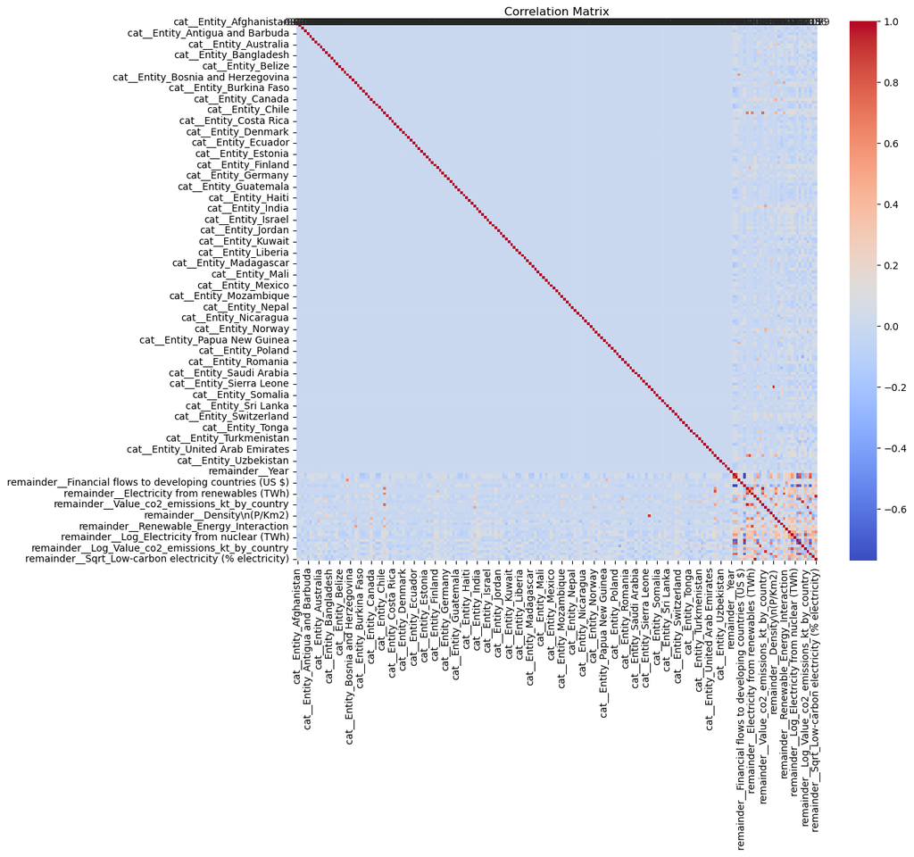

```python
corr_matrix = df_encoded.corr()
plt.figure(figsize=(12, 10))
sns.heatmap(corr_matrix, annot=True, cmap='coolwarm')
plt.title('Correlation Matrix')
plt.show()
```

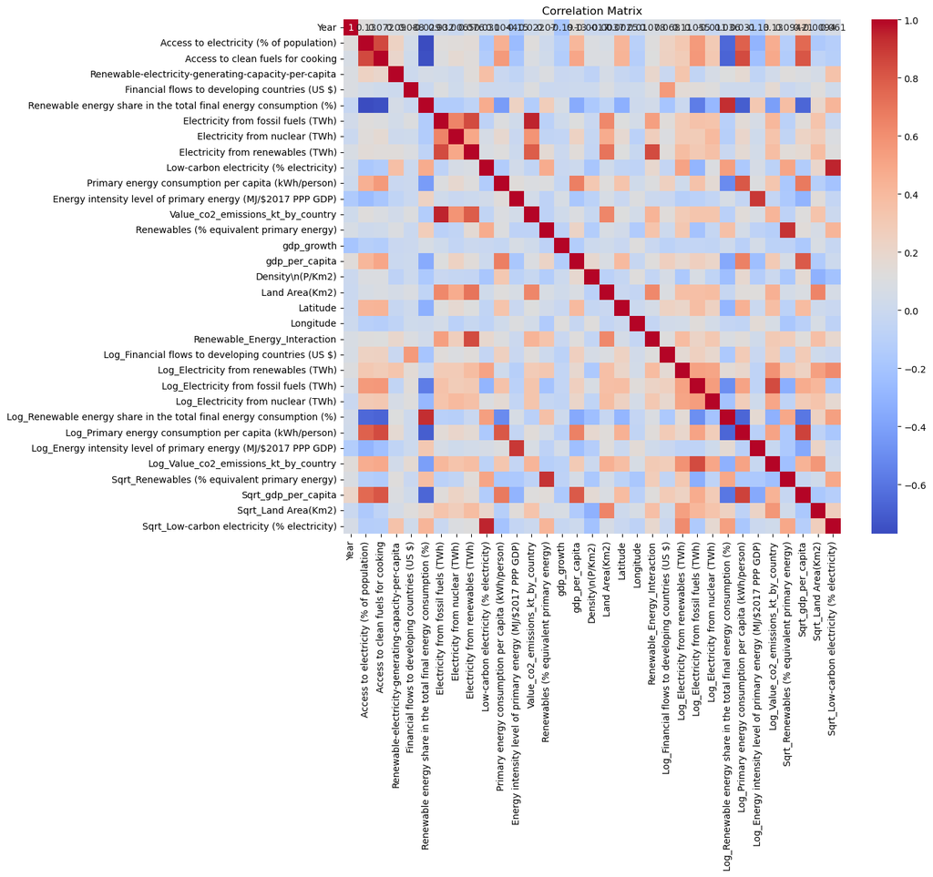

```python
# Exclude categorical columns like 'Entity'
numerical_df = df.select_dtypes(include=[np.number])

# Calculate the correlation matrix
corr_matrix = numerical_df.corr()

# Plot the correlation matrix
plt.figure(figsize=(12, 10))
sns.heatmap(corr_matrix, annot=True, cmap='coolwarm')
plt.title('Correlation Matrix')
plt.show()
```

#### I have assigned correlated features to a variable below:

```python
features = corr_matrix['gdp_growth'].sort_values(ascending=False).index[1:]
```

## 04. Regression Models

```python
from sklearn.dummy import DummyRegressor
from sklearn.metrics import r2_score
```

```python
# Select features for original data
X = df[features]
# Select features for transformed data
log_features = [
    'Log_Financial flows to developing countries (US $)', 'Log_Electricity from renewables (TWh)',
    'Log_Electricity from fossil fuels (TWh)', 'Log_Electricity from nuclear (TWh)',
    'Log_Renewable energy share in the total final energy consumption (%)',
    'Log_Primary energy consumption per capita (kWh/person)', 'Log_Energy intensity level of primary energy (MJ/$2017 PPP GDP)',
    'Log_Value_co2_emissions_kt_by_country','Sqrt_Renewables (% equivalent primary energy)',
    'Sqrt_gdp_per_capita', 'Sqrt_Land Area(Km2)', 'Sqrt_Low-carbon electricity (% electricity)'
]
X_log_transformed = df[log_features]
target = 'gdp_growth'
y = df[target]
```

```python
#Split data into training and testing sets
X_train_orig, X_test_orig, y_train, y_test = train_test_split(X, y, test_size=0.2, random_state=42)
X_train_log, X_test_log, y_train_log, y_test_log = train_test_split(X_log_transformed, y, test_size=0.2, random_state=42)
```

```python
# Scaling features
scaler = StandardScaler()
X_train_orig_scaled = scaler.fit_transform(X_train_orig)
X_test_orig_scaled = scaler.transform(X_test_orig)
X_train_log_scaled = scaler.fit_transform(X_train_log)
X_test_log_scaled = scaler.transform(X_test_log)
```

### Baseline Model (Mean Prediction)

```python
baseline_model = DummyRegressor(strategy='mean')
baseline_model.fit(X_train_orig_scaled, y_train)
y_pred_baseline = baseline_model.predict(X_test_orig_scaled)
r2_baseline = r2_score(y_test, y_pred_baseline)
print(f"Baseline Model R²: {r2_baseline}")
```

```
Baseline Model R²: -0.0007789910210975748
```

### Linear Regression Model

```python
#With Original data:
lin_reg_orig = LinearRegression()
lin_reg_orig.fit(X_train_orig_scaled, y_train)
y_pred_orig = lin_reg_orig.predict(X_test_orig_scaled)
r2_lin_orig = r2_score(y_test, y_pred_orig)
print(f"Linear Regression R² (Original Data): {r2_lin_orig}")
```

```
Linear Regression R² (Original Data): 0.1636642669346653
```

```python
#With transformed data:
lin_reg_log = LinearRegression()
lin_reg_log.fit(X_train_log_scaled, y_train_log)
y_pred_log = lin_reg_log.predict(X_test_log_scaled)
r2_lin_log = r2_score(y_test_log, y_pred_log)
print(f"Linear Regression R² (Transformed Data): {r2_lin_log}")
```

```
Linear Regression R² (Transformed Data): 0.08932513982431178
```

### Polynomial Regression Model

```python
#With Original Data
poly = PolynomialFeatures(degree=2)
X_train_poly_orig = poly.fit_transform(X_train_orig_scaled)
X_test_poly_orig = poly.transform(X_test_orig_scaled)

poly_reg_orig = LinearRegression()
poly_reg_orig.fit(X_train_poly_orig, y_train)
y_pred_poly_orig = poly_reg_orig.predict(X_test_poly_orig)
r2_poly_orig = r2_score(y_test, y_pred_poly_orig)
print(f"Polynomial Regression R² (Original Data): {r2_poly_orig}")
```

```
Polynomial Regression R² (Original Data): -0.34322206039139114
```

```python
#With transformed data
X_train_poly_log = poly.fit_transform(X_train_log_scaled)
X_test_poly_log = poly.transform(X_test_log_scaled)

poly_reg_log = LinearRegression()
poly_reg_log.fit(X_train_poly_log, y_train_log)
y_pred_poly_log = poly_reg_log.predict(X_test_poly_log)
r2_poly_log = r2_score(y_test_log, y_pred_poly_log)
print(f"Polynomial Regression R² (Transformed Data): {r2_poly_log}")
```

```
Polynomial Regression R² (Transformed Data): 0.140430005540632
```

### Ridge Regression Model

```python
#With Original Data
ridge = Ridge()
ridge.fit(X_train_orig_scaled, y_train)
y_pred_ridge_orig = ridge.predict(X_test_orig_scaled)
r2_ridge_orig = r2_score(y_test, y_pred_ridge_orig)
print(f"Ridge Regression R² (Original Data): {r2_ridge_orig}")
```

```
Ridge Regression R² (Original Data): 0.1636914751093227
```

```python
#With transformed data
ridge_log = Ridge()
ridge_log.fit(X_train_log_scaled, y_train_log)
y_pred_ridge_log = ridge_log.predict(X_test_log_scaled)
r2_ridge_log = r2_score(y_test_log, y_pred_ridge_log)
print(f"Ridge Regression R² (Log Data): {r2_ridge_log}")
```

```
Ridge Regression R² (Log Data): 0.08927599908353911
```

### Lasso Regression Model

```python
#With Original Data
lasso = Lasso()
lasso.fit(X_train_orig_scaled, y_train)
y_pred_lasso_orig = lasso.predict(X_test_orig_scaled)
r2_lasso_orig = r2_score(y_test, y_pred_lasso_orig)
print(f"Lasso Regression R² (Original Data): {r2_lasso_orig}")
```

```
Lasso Regression R² (Original Data): -1.3758879852776573e-05
```

```python
#With transformed data
lasso_log = Lasso()
lasso.fit(X_train_log_scaled, y_train_log)
y_pred_lasso_log = lasso.predict(X_test_log_scaled)
r2_lasso_log = r2_score(y_test_log, y_pred_lasso_log)
print(f"Lasso Regression R² (Log Data): {r2_lasso_log}")
```

```
Lasso Regression R² (Log Data): -0.0007789910210975748
```

### Elastic Net Regression Model

```python
#With Original Data
elastic_net = ElasticNet()
elastic_net.fit(X_train_orig_scaled, y_train)
y_pred_en_orig = elastic_net.predict(X_test_orig_scaled)
r2_en_orig = r2_score(y_test, y_pred_en_orig)
print(f"Elastic Net R² (Original Data): {r2_en_orig}")
```

```
Elastic Net R² (Original Data): 0.04376717387636131
```

#### Next let's do hyperparameter tuning:

```python
# Hyperparameter Tuning with Grid Search for Original Data

from sklearn.model_selection import GridSearchCV, cross_val_score

param_grid_ridge = {'alpha': [0.1, 1.0, 10.0]}
param_grid_lasso = {'alpha': [0.01, 0.1, 1.0]}
param_grid_elastic_net = {'alpha': [0.01, 0.1, 1.0], 'l1_ratio': [0.1, 0.5, 0.9]}

grid_search_ridge = GridSearchCV(Ridge(), param_grid_ridge, cv=5, scoring='r2')
grid_search_ridge.fit(X_train_orig_scaled, y_train)
print(f"Best Ridge Params: {grid_search_ridge.best_params_}")

grid_search_lasso = GridSearchCV(Lasso(), param_grid_lasso, cv=5, scoring='r2')
grid_search_lasso.fit(X_train_orig_scaled, y_train)
print(f"Best Lasso Params: {grid_search_lasso.best_params_}")

grid_search_elastic_net = GridSearchCV(ElasticNet(), param_grid_elastic_net, cv=5, scoring='r2')
grid_search_elastic_net.fit(X_train_orig_scaled, y_train)
print(f"Best Elastic Net Params: {grid_search_elastic_net.best_params_}")
```

```
Best Ridge Params: {'alpha': 10.0}
Best Lasso Params: {'alpha': 0.01}
Best Elastic Net Params: {'alpha': 0.01, 'l1_ratio': 0.1}
```

```python
# Hyperparameter Tuning with Grid Search for Log-Transformed Data

grid_search_ridge_log = GridSearchCV(Ridge(), param_grid_ridge, cv=5, scoring='r2')
grid_search_ridge_log.fit(X_train_log_scaled, y_train_log)
print(f"Best Ridge Params (Log Data): {grid_search_ridge_log.best_params_}")

grid_search_lasso_log = GridSearchCV(Lasso(), param_grid_lasso, cv=5, scoring='r2')
grid_search_lasso_log.fit(X_train_log_scaled, y_train_log)
print(f"Best Lasso Params (Log Data): {grid_search_lasso_log.best_params_}")

grid_search_elastic_net_log = GridSearchCV(ElasticNet(), param_grid_elastic_net, cv=5, scoring='r2')
grid_search_elastic_net_log.fit(X_train_log_scaled, y_train_log)
print(f"Best Elastic Net Params (Log Data): {grid_search_elastic_net_log.best_params_}")
```

```
Best Ridge Params (Log Data): {'alpha': 10.0}
Best Lasso Params (Log Data): {'alpha': 0.01}
Best Elastic Net Params (Log Data): {'alpha': 0.01, 'l1_ratio': 0.1}
```

#### Using the best hyperparamaters obtained, we will retrain the models:

```python
#Retrain Models with Best Hyperparameters
best_ridge = Ridge(alpha=grid_search_ridge.best_params_['alpha'])
best_ridge.fit(X_train_orig_scaled, y_train)
y_pred_ridge_tuned = best_ridge.predict(X_test_orig_scaled)
r2_ridge_tuned = r2_score(y_test, y_pred_ridge_tuned)
print(f"Ridge Regression R² (Tuned): {r2_ridge_tuned}")

best_lasso = Lasso(alpha=grid_search_lasso.best_params_['alpha'])
best_lasso.fit(X_train_orig_scaled, y_train)
y_pred_lasso_tuned = best_lasso.predict(X_test_orig_scaled)
r2_lasso_tuned = r2_score(y_test, y_pred_lasso_tuned)
print(f"Lasso Regression R² (Tuned): {r2_lasso_tuned}")

best_elastic_net = ElasticNet(alpha=grid_search_elastic_net.best_params_['alpha'],
                              l1_ratio=grid_search_elastic_net.best_params_['l1_ratio'])
best_elastic_net.fit(X_train_orig_scaled, y_train)
y_pred_en_tuned = best_elastic_net.predict(X_test_orig_scaled)
r2_en_tuned = r2_score(y_test, y_pred_en_tuned)
print(f"Elastic Net R² (Tuned): {r2_en_tuned}")
```

```
Ridge Regression R² (Tuned): 0.16366456032086285
Lasso Regression R² (Tuned): 0.16230897290888036
Elastic Net R² (Tuned): 0.16288997963658924
```

```python
best_ridge_log = Ridge(alpha=grid_search_ridge_log.best_params_['alpha'])
best_ridge_log.fit(X_train_log_scaled, y_train_log)
y_pred_ridge_tuned_log = best_ridge_log.predict(X_test_log_scaled)
r2_ridge_tuned_log = r2_score(y_test_log, y_pred_ridge_tuned_log)
print(f"Ridge Regression R² (Tuned, Log Data): {r2_ridge_tuned_log}")

best_lasso_log = Lasso(alpha=grid_search_lasso_log.best_params_['alpha'])
best_lasso_log.fit(X_train_log_scaled, y_train_log)
y_pred_lasso_tuned_log = best_lasso_log.predict(X_test_log_scaled)
r2_lasso_tuned_log = r2_score(y_test_log, y_pred_lasso_tuned_log)
print(f"Lasso Regression R² (Tuned, Log Data): {r2_lasso_tuned_log}")

best_elastic_net_log = ElasticNet(alpha=grid_search_elastic_net_log.best_params_['alpha'],
                                  l1_ratio=grid_search_elastic_net_log.best_params_['l1_ratio'])
best_elastic_net_log.fit(X_train_log_scaled, y_train_log)
y_pred_en_tuned_log = best_elastic_net_log.predict(X_test_log_scaled)
r2_en_tuned_log = r2_score(y_test_log, y_pred_en_tuned_log)
print(f"Elastic Net R² (Tuned, Log Data): {r2_en_tuned_log}")
```

```
Ridge Regression R² (Tuned, Log Data): 0.08881467949983324
Lasso Regression R² (Tuned, Log Data): 0.08912626000693813
Elastic Net R² (Tuned, Log Data): 0.08805024223239499
```

#### Below is the cross validation to find which model has the best R2:

```python
# Cross-validation for the Baseline Model
baseline_model = DummyRegressor(strategy='mean')
cv_baseline_scores = cross_val_score(baseline_model, X_train_orig_scaled, y_train, cv=5, scoring='r2')
print(f"Baseline Model Cross-Validated R²: {cv_baseline_scores.mean()}")

# Cross-validation for the Linear Regression Model (Original Data)
lin_reg = LinearRegression()
cv_lin_reg_scores = cross_val_score(lin_reg, X_train_orig_scaled, y_train, cv=5, scoring='r2')
print(f"Linear Regression Cross-Validated R² (Original Data): {cv_lin_reg_scores.mean()}")

# Cross-validation for the Ridge Regression Model
best_ridge = Ridge(alpha=grid_search_ridge.best_params_['alpha'])
cv_ridge_scores = cross_val_score(best_ridge, X_train_orig_scaled, y_train, cv=5, scoring='r2')
print(f"Ridge Regression Cross-Validated R²: {cv_ridge_scores.mean()}")

# Cross-validation for the Lasso Regression Model
best_lasso = Lasso(alpha=grid_search_lasso.best_params_['alpha'])
cv_lasso_scores = cross_val_score(best_lasso, X_train_orig_scaled, y_train, cv=5, scoring='r2')
print(f"Lasso Regression Cross-Validated R²: {cv_lasso_scores.mean()}")

# Cross-validation for the Elastic Net Model
best_elastic_net = ElasticNet(alpha=grid_search_elastic_net.best_params_['alpha'],
                              l1_ratio=grid_search_elastic_net.best_params_['l1_ratio'])
cv_elastic_net_scores = cross_val_score(best_elastic_net, X_train_orig_scaled, y_train, cv=5, scoring='r2')
print(f"Elastic Net Cross-Validated R²: {cv_elastic_net_scores.mean()}")
```

```
Baseline Model Cross-Validated R²: -0.0013086835417721154
Linear Regression Cross-Validated R² (Original Data): 0.0904437166245251
Ridge Regression Cross-Validated R²: 0.09160891860469307
Lasso Regression Cross-Validated R²: 0.08960078012909745
Elastic Net Cross-Validated R²: 0.09205439173469913
```

```python
# Cross-validation for the Linear Regression Model (Log Data)
lin_reg_log = LinearRegression()
cv_lin_reg_log_scores = cross_val_score(lin_reg_log, X_train_log_scaled, y_train_log, cv=5, scoring='r2')
print(f"Linear Regression Cross-Validated R² (Log Data): {cv_lin_reg_log_scores.mean()}")

# Cross-validation for the Ridge Regression Model (Log Data)
best_ridge_log = Ridge(alpha=grid_search_ridge.best_params_['alpha'])
cv_ridge_log_scores = cross_val_score(best_ridge_log, X_train_log_scaled, y_train_log, cv=5, scoring='r2')
print(f"Ridge Regression Cross-Validated R² (Log Data): {cv_ridge_log_scores.mean()}")

# Cross-validation for the Lasso Regression Model (Log Data)
best_lasso_log = Lasso(alpha=grid_search_lasso.best_params_['alpha'])
cv_lasso_log_scores = cross_val_score(best_lasso_log, X_train_log_scaled, y_train_log, cv=5, scoring='r2')
print(f"Lasso Regression Cross-Validated R² (Log Data): {cv_lasso_log_scores.mean()}")

# Cross-validation for the Elastic Net Model (Log Data)
best_elastic_net_log = ElasticNet(alpha=grid_search_elastic_net.best_params_['alpha'],
                                  l1_ratio=grid_search_elastic_net.best_params_['l1_ratio'])
cv_elastic_net_log_scores = cross_val_score(best_elastic_net_log, X_train_log_scaled, y_train_log, cv=5, scoring='r2')
print(f"Elastic Net Cross-Validated R² (Log Data): {cv_elastic_net_log_scores.mean()}")
```

```
Linear Regression Cross-Validated R² (Log Data): 0.06152978319512901
Ridge Regression Cross-Validated R² (Log Data): 0.06173705267654428
Lasso Regression Cross-Validated R² (Log Data): 0.061745467829835234
Elastic Net Cross-Validated R² (Log Data): 0.06178936319049053
```

## 05. Recommended Final Model

#### Based on the analysis, the Elastic Net regression model is recommended as the final model for predicting GDP growth. This recommendation stems from its superior performance compared to other models on the original data, achieving the highest R² score of 0.0921 during cross-validation. Elastic Net balances the benefits of L1 and L2 regularization, making it robust to multicollinearity and capable of handling high-dimensional data. This balance helps to avoid overfitting and enhances model generalizability. While the R² values of all models on the log-transformed data are similar and lower compared to the original data, Elastic Net’s performance on the original data stands out, providing a more accurate and stable prediction for GDP growth.

```
Elastic Net R² (Tuned): 0.16288997963658924
```

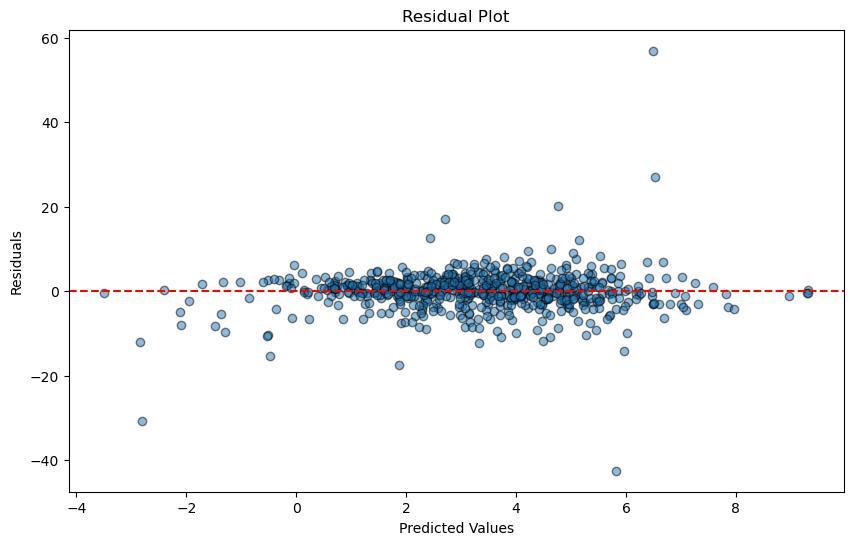

```python
def plot_residuals(model, X_test, y_test):
    y_pred = model.predict(X_test)
    residuals = y_test - y_pred

    plt.figure(figsize=(10, 6))
    plt.scatter(y_pred, residuals, alpha=0.5, edgecolor='k')
    plt.axhline(0, color='red', linestyle='--')
    plt.xlabel('Predicted Values')
    plt.ylabel('Residuals')
    plt.title('Residual Plot')
    plt.show()

# Fit the ElasticNet model with the best hyperparameters
best_elastic_net = ElasticNet(alpha=grid_search_elastic_net.best_params_['alpha'],
                              l1_ratio=grid_search_elastic_net.best_params_['l1_ratio'])
best_elastic_net.fit(X_train_orig_scaled, y_train)

# Make predictions and evaluate the model
y_pred_en_tuned = best_elastic_net.predict(X_test_orig_scaled)
r2_en_tuned = r2_score(y_test, y_pred_en_tuned)
print(f"Elastic Net R² (Tuned): {r2_en_tuned}")

# Plot residuals for the tuned ElasticNet model
plot_residuals(best_elastic_net, X_test_orig_scaled, y_test)
```

## 07. Suggestions for Next Steps

#### To further enhance the model's predictive power and interpretability, consider the following steps:

#### Feature Engineering: Explore additional feature interactions or polynomial terms that might capture non-linear relationships better. For instance, interaction terms between energy consumption and CO2 emissions could provide deeper insights into their combined effect on GDP growth.

#### Data Expansion: Integrate external datasets that could offer more context or additional variables affecting GDP growth, such as technological advancements, political stability indices, or trade metrics. This can help refine the model by incorporating more factors that influence economic growth.

#### Model Reassessment: Reevaluate the model with updated features or additional data to ensure it remains the best fit. Continuous monitoring and validation with new data will help maintain its relevance and accuracy over time.

#### Residual Analysis: Perform a detailed residual analysis to identify any patterns or outliers that may indicate areas for improvement. This can guide adjustments to the model or suggest new features for inclusion.